# Simulation-Based Inference (SBI) with variational inference

We'll go through some examples of Bayesian inference with SBI using variational inference to estimate the joint $p(\theta,\mathcal{D})$. We'll use the same examples as in the ABC demo and use `pytorch`.

```python
import torch
import numpy as np
import matplotlib.pyplot as plt
import corner
```

```python
torch.manual_seed(0)
```

```
<torch._C.Generator at 0x106f19890>
```

# Example 0

Let's return to the example from a few weeks ago

> Imagine a hypothetical simplistic example, where we point our telescope to observe the light from a single star with true flux $F_{\rm true}$, which remains constant with time. We will ignore any systematic errors. We perform $N$ measurements with our telescope, where the $i^{\rm th}$ measurement report an observed flux $F_i$ with uncertainty/error $e_i$.

Lets generate a synthetic observation

```python
F_true = 1000
F_obs = np.random.poisson(lam=F_true)
```

Let's write down the a simulation of the data generation process. In this case this is trivial because we know exactly the data generation process

```python
def simulation(F_true):
    return np.random.poisson(lam=F_true)
```

For our prior, lets use a simple Gaussian $$p(\theta) = \mathcal{N}(1002, 4)$$ This would hypothetically be measurement from a prior experiment

```python
# p(theta) = N(1002, 4)
def sample_prior():
    return 1002. + 4. *np.random.normal()
```

Then by repeating the following two steps,

1. sample the prior: $\theta'\sim p(\theta)$
2. run simulation: $\mathcal{D}' \sim F(\theta')$

We can sample $(\theta', \mathcal{D}') \sim p(\theta, \mathcal{D})$

```python
# now draw Nsample samples
Nsample = 10000

thetas, data = [], []
for i in range(Nsample):
    theta_p = sample_prior()
    data_p = simulation(theta_p)

    thetas.append(theta_p)
    data.append(data_p)

samples = np.array([thetas, data]).T
```

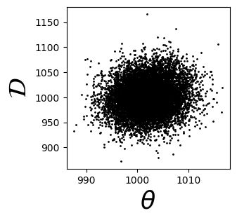

```python
# plot p(theta, D)
fig = plt.figure(figsize=(3,3))
sub = fig.add_subplot(111)
sub.scatter(np.array(thetas), np.array(data), s=1, c='k')
sub.set_xlabel(r'$\theta$', fontsize=25)
sub.set_ylabel('$\mathcal{D}$', fontsize=25)
```

## variational inference

Now lets use variational inference to estimate this joint distribution.

First, we need to select our surrogate distribution $q_\phi(\theta, \mathcal{D})$.

We'll use a simple 2D Gaussian, so the hyperparameter $\phi$ is the mean and covariance matrix

```python
def log_q(x, mean, cov):
    # log q_phi
    diff = x - mean

    # cholseky factorization to lower-triangular matrix
    L = torch.linalg.cholesky(cov)

    # triangular solve trick so we don't
    # have to invert the covariance matrix
    sol = torch.linalg.solve_triangular(
        L, diff.T, upper=False).T

    # log det --- det(Cov) = det(L)^2
    logdet = 2.0 * torch.sum(torch.log(torch.diag(L)))

    D = mean.shape[-1]
    return -0.5 * (D * torch.log(torch.tensor(2 * torch.pi)) + logdet
                   + torch.sum(sol ** 2, dim=-1))
```

Now lets determine $\phi$, the mean and covariance, by minimizing the KL divergence between $p(\theta, \mathcal{D})$ and $q_\phi(\theta, \mathcal{D})$:

$$D_{\rm KL} (p\parallel q_\phi) \approx \sum\limits_{(\theta',\mathcal{D}')\sim p(\theta, \mathcal{D})} \left[ - \log q_\phi(\theta',\mathcal{D}')\right]$$

Again, note that we're estimating the KL divergence using $(\theta',\mathcal{D}')\sim p(\theta, \mathcal{D})$ --- i.e. simulation-based inference!

```python
def KL(x, mu, A):
    '''KL divergence'''
    # some more common linear algebra tricks
    # A @ A.T ensure cov is positive semi-definite
    # 1e-3 * I ensures its symmetric positive definite
    cov = A @ A.T + 1e-3 * torch.eye(A.shape[0], device=A.device)
    return -torch.mean(log_q(x, mu, cov))
```

initialize $\phi$ and optimize using `Adam`

```python
mu = torch.tensor([1002.0, 1002.0], requires_grad=True)
A  = torch.tensor([[4.0, 0.0], [0.0, 30.0]], requires_grad=True)
```

```python
optimizer = torch.optim.Adam([mu, A], lr=0.01)
```

```python
for t in range(2001):
    optimizer.zero_grad()
    loss = KL(torch.tensor(samples), mu, A)
    loss.backward()
    optimizer.step()

    if t % 200 == 0:
        cov = (A @ A.T + 1e-3 * torch.eye(2)).detach()
        print(f"step {t:4d} | loss {loss.item():.4f} | "
              f"mu {mu.detach().numpy()} | "
              f"cov diag [{cov[0,0]:.2f}, {cov[1,1]:.2f}]")
```

```
step    0 | loss 7.6915 | mu [1002.01 1002.01] | cov diag [15.92, 900.60]
step  200 | loss 7.6779 | mu [1002.01575 1002.20233] | cov diag [15.59, 995.37]
step  400 | loss 7.6774 | mu [1002.01575 1002.20233] | cov diag [15.60, 1032.40]
step  600 | loss 7.6774 | mu [1002.01575 1002.20233] | cov diag [15.60, 1040.24]
step  800 | loss 7.6774 | mu [1002.01575 1002.20233] | cov diag [15.60, 1041.11]
step 1000 | loss 7.6774 | mu [1002.01575 1002.20233] | cov diag [15.60, 1041.15]
step 1200 | loss 7.6774 | mu [1002.0157  1002.20233] | cov diag [15.60, 1041.15]
step 1400 | loss 7.6774 | mu [1002.0158  1002.20233] | cov diag [15.60, 1041.15]
step 1600 | loss 7.6774 | mu [1002.0158 1002.2023] | cov diag [15.60, 1041.15]
step 1800 | loss 7.6774 | mu [1002.01575 1002.20233] | cov diag [15.60, 1041.15]
step 2000 | loss 7.6774 | mu [1002.0158 1002.2023] | cov diag [15.60, 1041.15]
```

Lets check how well $q_\phi(\theta, \mathcal{D})$ approximates $p(\theta, \mathcal{D})$

```python
q_samples = np.random.multivariate_normal(
    np.array(mu.detach().numpy()),
    np.array(A.detach().numpy() @ A.detach().numpy().T), size=100000)
```

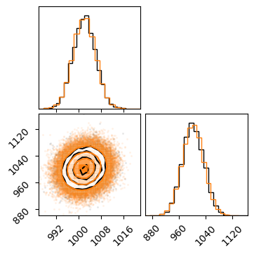

```python
fig = plt.figure(figsize=(4,4))
fig = corner.corner(np.array(samples), hist_kwargs={"density": True}, fig=fig)
fig = corner.corner(q_samples, color='C1', hist_kwargs={"density": True}, fig=fig)
```

looks pretty good!

```python
q_samples = np.random.multivariate_normal(
    np.array(mu.detach().numpy()),
    np.array(A.detach().numpy() @ A.detach().numpy().T), size=10000000)
close_enough = np.abs(q_samples[:,1] - F_obs) < 1
print('%i have D \approx D_obs' % np.sum(close_enough))
```

```
188271 have D pprox D_obs
```

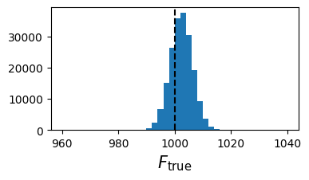

```python
plt.figure(figsize=(4,2))
plt.hist(q_samples[:,0][close_enough], range=(960, 1040), bins=40)
plt.axvline(F_true, color='k', linestyle='--')
plt.xlabel(r'$F_{\rm true}$', fontsize=15); plt.show()
```

This is a bit of a silly example since the simulator is very cheap to run. But in many astrophysical applications the simulator of the data generation process is very expensive (cosmological simulations), then it would make sense to sample the joint distribution using the surrogate!

# Example 1

Now that was a very simple 1D example. Lets consider a slightly more interesting example of fitting a line to some data and see how SBI with variational inference holds up.

First, we'll go through the example with a slight modification: Gaussian priors rather than uniform priors.

```python
a_true, b_true = 0, 1.75
x = np.array([1, 1.5, 2, 2.5])
y = np.array([1.87640523, 2.59001572, 3.4978738 , 4.47408932])
yerr = 0.1
```

```
<ErrorbarContainer object of 3 artists>
```

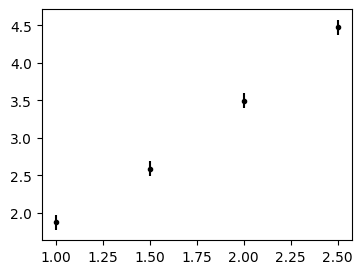

```python
plt.figure(figsize=(4,3))
plt.errorbar(x, y, yerr=yerr, fmt='.k')
```

same as above, sample $\theta', \mathcal{D}' \sim p(\theta, \mathcal{D})$ using prior and simulator

```python
def simulation(theta):
    a, b = theta
    noise = yerr * np.random.normal(size=len(x))
    return a + b * x + noise

def sample_prior():
    # sample a and b from uniform prior
    _a = -0.5 + np.random.normal()
    _b = 5 + 3*np.random.normal()
    return [_a, _b]
```

```python
Nsample = 50000

samples = np.zeros((Nsample, 6))
for i in range(Nsample):
    theta_p = sample_prior()
    data_p = simulation(theta_p)
    samples[i,:] = np.concatenate([theta_p, data_p])
```

Initialize and optimize $\phi$. We can use the `log_q` and `KL` functions from earlier.

```python
mu = torch.tensor([0., 2., 5., 5., 10., 10.], requires_grad=True)
A  = torch.diag(torch.tensor([1, 3., 3., 4., 6, 7.5])).requires_grad_(True)
```

```python
optimizer = torch.optim.Adam([mu, A], lr=0.01)
```

```python
for t in range(2001):
    optimizer.zero_grad()
    loss = KL(torch.tensor(samples), mu, A)
    loss.backward()
    optimizer.step()

    if t % 200 == 0:
        cov = (A @ A.T + 1e-3 * torch.eye(6)).detach()
        print(f"step {t:4d} | loss {loss.item():.4f} | ")
```

```
step    0 | loss 16.9565 |
step  200 | loss 5.8767 |
step  400 | loss 0.5834 |
step  600 | loss 0.5307 |
step  800 | loss 0.5146 |
step 1000 | loss 0.5031 |
step 1200 | loss 0.4949 |
step 1400 | loss 0.4891 |
step 1600 | loss 0.4857 |
step 1800 | loss 0.4822 |
step 2000 | loss 0.4809 |
```

Lets again check $q_\phi(\theta, \mathcal{D})$ against $p(\theta, \mathcal{D})$

```python
q_samples = np.random.multivariate_normal(
    np.array(mu.detach().numpy()),
    np.array(A.detach().numpy() @ A.detach().numpy().T) + 1e-3 * np.eye(6),
    size=100000)
```

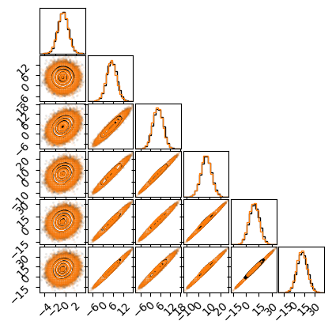

```python
fig = plt.figure(figsize=(4,4))
fig = corner.corner(np.array(samples), hist_kwargs={'density': True}, fig=fig)
fig = corner.corner(q_samples, color='C1', hist_kwargs={'density': True}, fig=fig)
```

comparison of $q_\phi$ to $p$ looks pretty good. Let's move on to the ABC approximation

```python
q_samples = np.random.multivariate_normal(
    np.array(mu.detach().numpy()),
    np.array(A.detach().numpy() @ A.detach().numpy().T) + 1e-3 * np.eye(6),
    size=10000000)
```

```python
# ABC using distance criteria rho(D, D_obs) < epsilon
rho = np.sqrt(np.sum((q_samples[:,2:] - y[None, :])**2, axis=1))
```

```python
epsilon = 0.2
print('reject %f percent of simulations' % (100.*(1-np.mean(rho < epsilon))))
```

```
reject 99.946920 percent of simulations
```

Because we using a surrogate that is very easy to sample, we can afford to reject 99.95% of the samples!

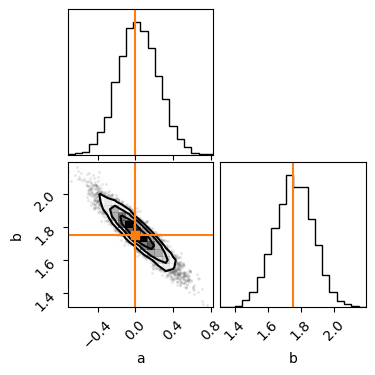

```python
fig = plt.figure(figsize=(4,4))
fig = corner.corner(q_samples[:,:2][rho < epsilon], labels=['a', 'b'], fig=fig)
corner.overplot_lines(fig, [a_true, b_true], color="C1")
corner.overplot_points(fig, np.array([a_true, b_true])[None], marker="s", color="C1")
```

posterior looks pretty good!

# Example 1.b

Now what happens if we change the prior back to the uniform priors, instead of the Gaussian priors

```python
def simulation(theta):
    a, b = theta
    noise = yerr * np.random.normal(size=len(x))
    return a + b * x + noise

def sample_prior():
    # sample a and b from uniform prior
    _a = -0.5 + np.random.uniform()
    _b = 10*np.random.uniform()
    return [_a, _b]

Nsample = 500000

samples = np.zeros((Nsample, 6))
for i in range(Nsample):
    theta_p = sample_prior()
    data_p = simulation(theta_p)
    samples[i,:] = np.concatenate([theta_p, data_p])
```

```python
mu = torch.tensor([0., 2., 5., 5., 10., 10.], requires_grad=True)
A  = torch.diag(torch.tensor([1, 3., 3., 4., 6, 7.5])).requires_grad_(True)

optimizer = torch.optim.Adam([mu, A], lr=0.01)

for t in range(2001):
    optimizer.zero_grad()
    loss = KL(torch.tensor(samples), mu, A)
    loss.backward()
    optimizer.step()

    if t % 200 == 0:
        cov = (A @ A.T + 1e-3 * torch.eye(6)).detach()
        print(f"step {t:4d} | loss {loss.item():.4f} | ")
```

```
step    0 | loss 16.1406 |
step  200 | loss 5.0795 |
step  400 | loss -0.7102 |
step  600 | loss -0.7347 |
step  800 | loss -0.7542 |
step 1000 | loss -0.7679 |
step 1200 | loss -0.7785 |
step 1400 | loss -0.7861 |
step 1600 | loss -0.7911 |
step 1800 | loss -0.7951 |
step 2000 | loss -0.7978 |
```

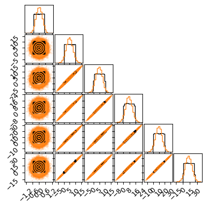

```python
q_samples = np.random.multivariate_normal(
    np.array(mu.detach().numpy()),
    np.array(A.detach().numpy() @ A.detach().numpy().T) + 1e-3 * np.eye(6),
    size=100000)
fig = plt.figure(figsize=(4,4))
fig = corner.corner(np.array(samples), hist_kwargs={'density': True}, fig=fig)
fig = corner.corner(q_samples, color='C1', hist_kwargs={'density': True}, fig=fig)
```

Now you can see why I chose Gaussian priors earlier.

With uniform priors, we're confronted with a key challenge with variational inference.

Our multivariate Gaussian surrogate cannot estimate $p(\theta, \mathcal{D})$ accurately. In this case, there's no way to accurately estimate the posterior with $q_\phi$.

Since $q_\phi$ does not accurately estimate $p(\theta, \mathcal{D})$, we cannot proceed with the Bayesian inference

# unit summary

- SBI enables us to sample $p(\theta, \mathcal{D})$ even when we don't have access to the explicit likelihood
- Using variational inference we can estimate $p(\theta, \mathcal{D})$ with a surrogate $q_\phi$ that is easy to sample, then use ABC for Bayesian inference
- we can implement SBI with VI in `pytorch`
- **caution**: SBI + VI, as with VI, is sensitive to the choice of $q_\phi$